Ullrich Köthe: **Fundamentals of Machine Learning**, Winter Semester 2020/21  
Notebook created by Felix Draxler & Jakob Kruse & Nicolas Roth & Jens Beyermann

# Solutions for Exercise 1

In order to run this notebook, you have to install the `pandas` package:  
`conda install pandas`

```python
import numpy as np
import matplotlib.pyplot as plt
import pandas as pd
pd.options.display.float_format = '{:,.2f}'.format
```

# 1 Monte-Carlo simulation

Wikipedia entry: [**Inverse transform sampling**](https://en.wikipedia.org/wiki/Inverse_transform_sampling)

Probability density functions (pdf): $$ p(\,X\,|\,Y= 0\,) = f_0(x) = \begin{cases} 2 - 2x, & x \in [0,1] \\ 0, & \text{otherwise} \end{cases} $$

$$ p(\,X\,|\,Y= 1\,) = f_1(x) = \begin{cases} 2x, & x \in [0,1] \\ 0, & \text{otherwise} \end{cases} $$

Cumulative distribution functions (cdf) for $x\in[0,1]$:

\begin{align} P(\, X < x\,|\, Y = 0\,) &= F_{X,0}(x) = \int _{-\infty}^{x} f_0(t) \,dt \\ &= \int _{0}^{x} (2 - 2t) \,dt = [\, 2t - t^2 \,]_{0}^x \\ &= 2x - x^2 = u \end{align}

\begin{align} P(\, X < x\,|\, Y = 1\,) &= F_{X,1}(x) = \int _{-\infty}^{x} f_1(t) \,dt \\ &= \int _{0}^{x} 2t \,dt = [\, t^2 \,]_{0}^x \\ &= x^2 = u \end{align}

Inverse cumulative distribution functions (solve the above for $u\in[0,1]$): $$ F_{X,0}^{-1}(u) = 1 - \sqrt{1-u} $$

$$ F_{X,1}^{-1}(u) = \sqrt{u} $$

## 1.1 Data Creation and Visualization

```python
def create_data(N):
    data = np.zeros((N, 2), dtype = np.float32)
    for i in range(N):
        # sample y uniformly between 0 and 1
        y = np.random.randint(2)
        # use inverse transform sampling for x, given y
        u = np.random.rand()
        if 0 == y:
            x = 1 - np.sqrt(1 - u)
        else:
            x = np.sqrt(u)
        data[i,:] = (x,y)
    return data
```

```python
# create a data set to visualize the distributions
test_data = create_data(100000)
X_0 = test_data[test_data[:,1] == 0][:,0]
X_1 = test_data[test_data[:,1] == 1][:,0]
```

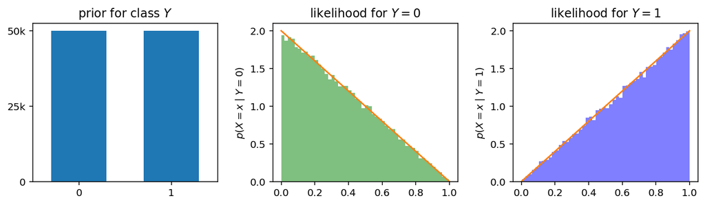

```python
# show prior and likelihoods for both classes as bar chart and histograms
fig = plt.figure(figsize = (10, 3))

plt.subplot(131)
plt.title(r'prior for class $Y$')
plt.bar([0, 1], [X_0.size, X_1.size], width = 0.6)
plt.xticks([0,1]); plt.xlim([-0.5, 1.5]); plt.yticks([0,25000,50000], ['0', '25k', '50k'])

plt.subplot(132)
plt.title(r'likelihood for $Y = 0$')
plt.hist(X_0, 50, density = True, facecolor = 'green', alpha = 0.5)
plt.ylabel(r'$p(X = x \mid Y = 0)$')
plt.plot([0,1], [2,0])

plt.subplot(133)
plt.title(r'likelihood for $Y = 1$')
plt.hist(X_1, 50, density = True, facecolor = 'blue', alpha = 0.5)
plt.ylabel(r'$p(X = x \mid Y = 1)$')
plt.plot([0,1], [0,2])

plt.tight_layout()
```

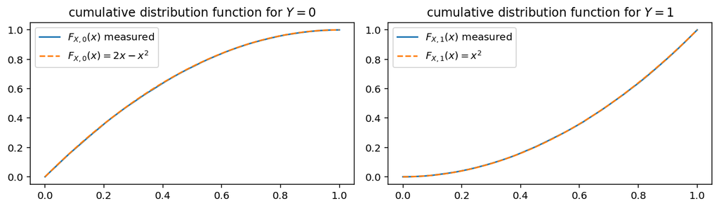

```python
# show cumulative distribution functions for both classes as plots
fig = plt.figure(figsize=(10, 3))
domain = np.linspace(0, 1, 50)


plt.subplot(121)
plt.title(r'cumulative distribution function for $Y = 0$')

cdf_0 = np.array([np.count_nonzero(X_0 < t) for t in domain], dtype=float)
cdf_0 /= cdf_0.max()

plt.plot(domain, cdf_0, label = r'$F_{X,0}(x)$ measured')
plt.plot(domain, 2*domain - np.square(domain), '--', label=r'$F_{X,0}(x) = 2x - x^2$')
plt.legend()


plt.subplot(122)
plt.title(r'cumulative distribution function for $Y = 1$')

cdf_1 = np.array([np.count_nonzero(X_1 < t) for t in domain], dtype=float)
cdf_1 /= cdf_1.max()

plt.plot(domain, cdf_1, label = r'$F_{X,1}(x)$ measured')
plt.plot(domain, np.square(domain), '--', label = r'$F_{X,1}(x) = x^2$')
plt.legend()

fig.tight_layout()
```

## 1.2 Classification by Thresholding

```python
def evaluate_classifier(M, run_count, classifier, create_data=create_data):
    """
    Helper function to evaluate a classifier on a number of independent
    test sets of specified size.

    params
    ------
    M : int
        Data set size.
    run_count : int
        Amount of datasets the classifier is tested on.
    classifier : callable
        Function taking individual x values and returning the corresponding classification.

    returns
    -------
    np.array shape=(run_count)
        Error rates in [0, 100] for each run.
    """
    results = np.zeros(run_count)

    for i in range(run_count):
        data = create_data(M)

        # Count the wrong results
        wrong = 0
        for data_point in data:
            x, y_true = data_point
            y_pred = classifier(x)
            if y_true != y_pred:
                wrong += 1
        results[i] = wrong

    return results * 100 / M
```

```python
ts = [0.2, 0.5, 0.6]
Ms = [10, 100, 1000, 10000]
run_count = 10

# Compare several runs for different values of threshold and dataset size
results_A = []
results_B = []
for t in ts:
    # For clarity, write this after definition of t
    def pred_A(x): return 0 if x <= t else 1
    def pred_B(x): return 1 if x <= t else 0

    for M in Ms:
        # Compute error for rule A
        error_rates_A = evaluate_classifier(M, run_count, pred_A)
        results_A.append({
            "$x_t$": t,
            "$M$": M,
            "mean": error_rates_A.mean(),
            "std": error_rates_A.std()
        })

        # Compute error for rule B
        error_rates_B = evaluate_classifier(M, run_count, pred_B)
        results_B.append({
            "$x_t$": t,
            "$M$": M,
            "mean": error_rates_B.mean(),
            "std": error_rates_B.std()
        })
```

Let's look at the data. We use a [Pandas DataFrame](https://pandas.pydata.org/docs/getting_started/intro_tutorials/) for handling the data. It allows data handling and plotting a breeze (once you get used to the sometimes not intuitive naming).

```python
df_A = pd.DataFrame(results_A)
df_A = df_A.groupby(["$x_t$", "$M$"]).first().unstack()
df_A
```

| $M$ $x_t$ | mean 10 | mean 100 | mean 1000 | mean 10000 | std 10 | std 100 | std 1000 | std 10000 |
| --- | --- | --- | --- | --- | --- | --- | --- | --- |
| 0.20 | 34.00 | 35.40 | 34.65 | 34.09 | 12.00 | 3.83 | 1.23 | 0.43 |
| 0.50 | 31.00 | 24.10 | 25.40 | 24.89 | 15.13 | 3.21 | 1.22 | 0.38 |
| 0.60 | 26.00 | 26.30 | 26.69 | 25.98 | 14.97 | 4.00 | 1.22 | 0.34 |

```python
df_B = pd.DataFrame(results_B)
df_B = df_B.groupby(["$x_t$", "$M$"]).first().unstack()
df_B
```

| $M$ $x_t$ | mean 10 | mean 100 | mean 1000 | mean 10000 | std 10 | std 100 | std 1000 | std 10000 |
| --- | --- | --- | --- | --- | --- | --- | --- | --- |
| 0.20 | 61.00 | 65.10 | 65.84 | 65.64 | 15.78 | 4.16 | 1.62 | 0.23 |
| 0.50 | 74.00 | 74.70 | 75.44 | 74.86 | 15.62 | 4.43 | 1.70 | 0.23 |
| 0.60 | 73.00 | 72.30 | 74.20 | 73.94 | 13.45 | 4.92 | 1.51 | 0.33 |

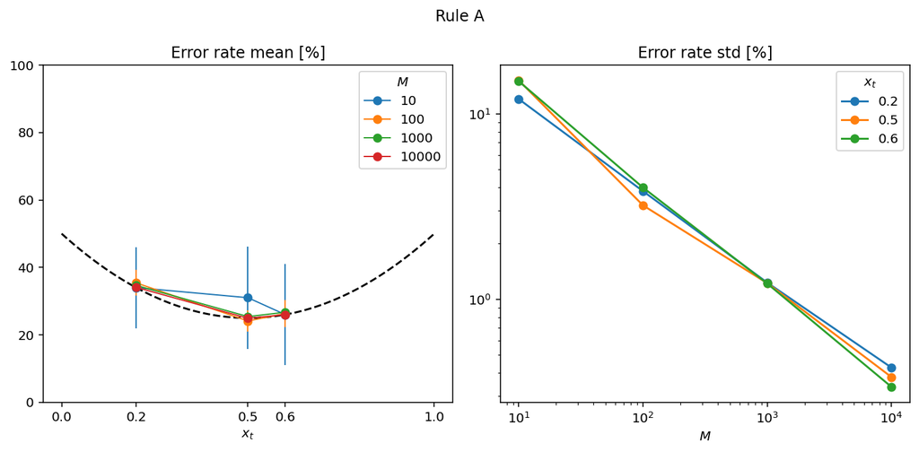

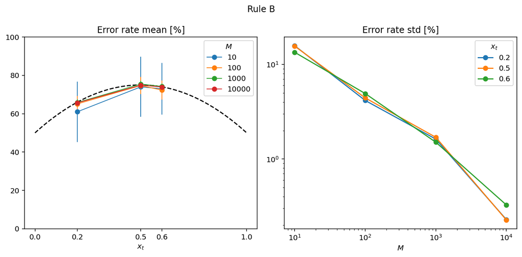

```python
# Show true errors as comparison
def error_A(t): return 100 * (0.25 + np.square(t - 0.5))
def error_B(t): return 100 * (0.75 - np.square(t - 0.5))

continuous_ts = np.linspace(0, 1, 100)
for name, df, true_error in zip(["A", "B"], [df_A, df_B], [error_A, error_B]):
    # This creates two plots next to one another in a new figure
    fig, (ax1, ax2) = plt.subplots(1, 2, figsize=(10, 5))
    plt.suptitle(f"Rule {name}")

    # First plot: Error rate mean confirms true error
    plt.sca(ax1)
    plt.ylim(0, 100)
    plt.title("Error rate mean [%]")
    df["mean"].plot(marker="o", yerr=df["std"], lw=1, ax=ax1)
    plt.plot(continuous_ts, true_error(continuous_ts), "k--")
    plt.xticks([0] + ts + [1])

    # Second plot: Error rate std declines with more samples
    plt.sca(ax2)
    plt.title("Error rate std [%]")
    df["std"].T.plot(marker="o", ax=ax2, logx=True, logy=True)

    plt.tight_layout()
```

We note two things:

- Rule A has always a higher accuracy than rule B, but no classifier can ever reach zero error.
- Using larger test sets yields a more accurate estimation of the error.

## 1.3 Baseline Classifiers

```python
# These classifiers ignore the input x
def pred_C(x): return np.random.randint(2)
def pred_D(x): return 1

# true error rates
def error_C(): return 50
def error_D(): return 50

# Collect data over different values of M
data_C = []
data_D = []
for M in Ms:
    error_C = evaluate_classifier(M, run_count, pred_C)
    data_C.append({
        "$M$": M,
        "mean": error_C.mean(),
        "std": error_C.std()
    })

    error_D = evaluate_classifier(M, run_count, pred_D)
    data_D.append({
        "$M$": M,
        "mean": error_D.mean(),
        "std": error_D.std()
    })
```

```python
df_C = pd.DataFrame(data_C)
df_C.set_index("$M$", inplace=True)
df_C
```

| $M$ | mean | std |
| --- | --- | --- |
| 10 | 52.00 | 13.27 |
| 100 | 50.50 | 5.04 |
| 1000 | 50.11 | 1.66 |
| 10000 | 49.89 | 0.33 |

```python
df_D = pd.DataFrame(data_D)
df_D.set_index("$M$", inplace=True)
df_D
```

| $M$ | mean | std |
| --- | --- | --- |
| 10 | 52.00 | 21.82 |
| 100 | 50.30 | 5.18 |
| 1000 | 50.58 | 1.32 |
| 10000 | 49.97 | 0.67 |

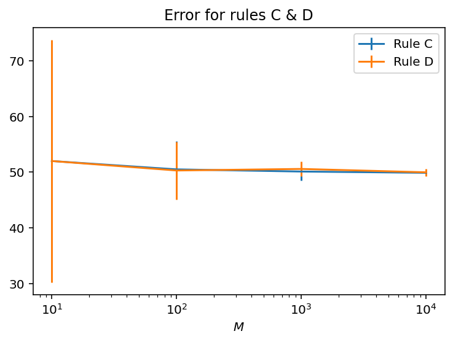

```python
df_C.plot(y="mean", yerr="std", logx=True, color="C0", ax=plt.gca(), label="Rule C")
df_D.plot(y="mean", yerr="std", logx=True, color="C1", ax=plt.gca(), label="Rule D")
plt.title("Error for rules C & D"); # ';' removes the output of the cell that Jupyter would show
```

## 1.4 Nearest Neighbor Classification

Create a large test set so that we get low error rates.

```python
testset = create_data(10000)
```

```python
# Nearest neighbour classifier for arbitrary training set size
def nn_classifier(x_test, x_train):
    """
    Nearest neighbor classifier for arbitrary training set size.

    params
    ------
    x_test : float
        A single sample to classify.
    x_train : np.array shape=(samples, 2)
        Training data for the classifier.
        First column contains feature data,
        the second one the correct label.

    returns
    -------
    label: [0, 1]
        Predicted label of the x_test sample.
    """
    diff = np.abs(x_train[:, 0] - x_test)
    idx = np.argmin(diff)
    label = x_train[idx, 1]
    return label
```

```python
errors = []
for i in range(100):
    # training set with one sample from each class
    x0 = 1 - np.sqrt(1 - np.random.rand()) # class 0
    x1 = np.sqrt(np.random.rand()) # class 1
    train_set = np.array([[x0, 0],
                          [x1, 1]])

    # evaluate on test set
    n_errors = 0
    for xy in testset:
        if nn_classifier(xy[0], train_set) != xy[1]: n_errors += 1
    errors.append(float(n_errors) / len(testset))
print(f'Average error: {100 * np.mean(errors):.1f}% ± {100 * np.std(errors):.1f}%')
```

```
Average error: 35.2% ± 16.4%
```

```python
# generate balanced training data
def gen_balanced_data(n):
    X0 = np.empty((n // 2, 2))
    X1 = np.empty((n // 2, 2))
    for i in range(n // 2):
        X0[i, 0] = 1 - np.sqrt(1 - np.random.rand())
        X0[i, 1] = 0
        X1[i, 0] = np.sqrt(np.random.rand())
        X1[i, 1] = 1
    return np.vstack((X0, X1))
```

```python
# repeat experiment with training_set of size N = 100

errors = []
for i in range(100):
    # training set with 50 samples from each class
    N = 100
    train_set = gen_balanced_data(N)
    # evaluate on test set
    n_errors = 0
    for xy in testset:
        if nn_classifier(xy[0], train_set) != xy[1]: n_errors += 1
    errors.append(float(n_errors) / len(testset))

print('Average error: {}% ± {}%'.format(np.round(100 * np.mean(errors), 2), np.round(100 * np.std(errors), 2)))
```

```
Average error: 32.94% ± 2.15%
```

**Comment**  
This experiment reduces the error only by a small amount. To explain this we have to consider that the probabilities for the two classes have high overlap. Therefore, a higher number of training examples will also include a higher number of instances that are located in the "wrong" region by chance. Those points lead to misclassifications. The method does still profit from more training data since proportion of "correct" points in the corresponding region increases, but the benefit is not as big as one would hope. We derive the theoretical asymptotic error in the next homework. Moreover, better results can be achieved with a k-nearest-neighbor method since the majority of several near neighbors is more accurate here. This algorithm is also covered in the next homework.